# R Assessment

## Setting Up

1. Install RStudio on your computer. Create a directory named `Assessment` somewhere on your computer and add an empty file named `answers.R` in it. Switch to that directory in RStudio and set the directory as your current working directory. Upload an image.
2. Clear all variables in the workspace. It’s best to do this before any project.

```r
rm(list=ls())
```

3. In this exercise we will need the `dplyr` and `ggplot2` libraries. Install these packages if you don’t have it, otherwise load it.

```r
library('dplyr')
```

```r
library('ggplot2')
```

4. Load the file `data1.csv` into the data frame `ads`.

```r
ads <- read.csv('data1.csv')
```

## Basic Data Analysis

4. What are the column names of this data frame?

```r
colnames(ads)
```

```
## [1] "id"         "date"       "channel"    "type"       "conversion"
## [6] "cost"       "revenue"
```

5. How may rows does the data frame have?

```r
nrow(ads)
```

```
## [1] 1000
```

6. Give an initial summary of the data frame

```r
summary(ads)
```

```
##        id              date          channel    type      conversion
##  Min.   :100000   Min.   :  1.0   display:253   A:323   Min.   :0.000
##  1st Qu.:100250   1st Qu.: 86.0   email  :246   B:343   1st Qu.:0.000
##  Median :100500   Median :168.0   print  :253   C:334   Median :0.000
##  Mean   :100500   Mean   :175.3   search :248           Mean   :0.189
##  3rd Qu.:100749   3rd Qu.:260.0                         3rd Qu.:0.000
##  Max.   :100999   Max.   :364.0                         Max.   :1.000
##       cost          revenue
##  Min.   :0.000   Min.   :15.10
##  1st Qu.:0.510   1st Qu.:17.43
##  Median :1.040   Median :18.86
##  Mean   :1.012   Mean   :18.95
##  3rd Qu.:1.540   3rd Qu.:20.53
##  Max.   :2.000   Max.   :22.66
```

7. Count up the total number of conversions over all ads.

```r
sum(ads$conversion)
```

```
## [1] 189
```

8. Filter our all impressions from the `display` channel that cost over $1. Save the result in the data frame `expensive.ads`

```r
expensive.ads<- ads[(ads$cost > 1)& (ads$channel=='display'),]
```

9. For the ads in the previous question, what was the total spent?

```r
sum(expensive.ads$cost)
```

```
## [1] 180.61
```

## Datatable Manipulation

9. Add a column which for each ad represents the profit. Compute the total profit.

```r
ads$profit <- ads$revenue - ads$cost
sum(ads$profit)
```

```
## [1] 17936.26
```

10. Create a new data frame that for each channel shows the total impressions, total conversions, and total cost.

```r
channel.per <- ads %>% group_by(channel) %>% summarise(total.impressions=n(), total.conversions=sum(conversion), total.cost=sum(cost))
print(channel.per)
```

```
## # A tibble: 4 x 4
##   channel total.impressions total.conversions total.cost
##   <fct>               <int>             <int>      <dbl>
## 1 display               253                54       242.
## 2 email                 246                49       265.
## 3 print                 253                43       263.
## 4 search                248                43       242.
```

11. Now import `data2.csv` into a data frame called `customers` and merge `ads` and `customers` on `id` calling the final data frame `merged`.

```r
customers <- read.csv('data2.csv')
merged <- merge(ads,customers,by="id")
```

## Analysis

12. Construct a regression between the age of the customers and spend of a customer.

```r
reg1 <- lm(revenue~age, data=merged)
print(reg1)
```

```
##
## Call:
## lm(formula = revenue ~ age, data = merged)
##
## Coefficients:
## (Intercept)          age
##     10.9938       0.2006
```

13. What is the $R^2$ of this regression?

```r
summary(reg1)
```

```
##
## Call:
## lm(formula = revenue ~ age, data = merged)
##
## Residuals:
##      Min       1Q   Median       3Q      Max
## -1.02719 -0.49000  0.02142  0.48936  0.98828
##
## Coefficients:
##              Estimate Std. Error t value Pr(>|t|)
## (Intercept) 10.993789   0.084186  130.59   <2e-16 ***
## age          0.200618   0.002073   96.78   <2e-16 ***
## ---
## Signif. codes:  0 '***' 0.001 '**' 0.01 '*' 0.05 '.' 0.1 ' ' 1
##
## Residual standard error: 0.5763 on 998 degrees of freedom
## Multiple R-squared:  0.9037, Adjusted R-squared:  0.9036
## F-statistic:  9366 on 1 and 998 DF,  p-value: < 2.2e-16
```

14. Using the regression predict the spend of a customer who is 38.

```r
predict(reg1, newdata = data.frame(age = c(38)))
```

```
##        1
## 18.61729
```

15. Using GLM, construct a regression between the Ad type and the conversions.

```r
reg2 <- glm(conversion~type, data=merged, family='binomial')
print(reg2)
```

```
##
## Call:  glm(formula = conversion ~ type, family = "binomial", data = merged)
##
## Coefficients:
## (Intercept)        typeB        typeC
##    -1.49841      0.04518      0.07809
##
## Degrees of Freedom: 999 Total (i.e. Null);  997 Residual
## Null Deviance:       969.5
## Residual Deviance: 969.4     AIC: 975.4
```

16. What coefficients appear in the previous regression?

```r
reg2 <- glm(conversion~type, data=merged, family='binomial')
summary(reg2)
```

```
##
## Call:
## glm(formula = conversion ~ type, family = "binomial", data = merged)
##
## Deviance Residuals:
##     Min       1Q   Median       3Q      Max
## -0.6579  -0.6579  -0.6482  -0.6351   1.8440
##
## Coefficients:
##             Estimate Std. Error z value Pr(>|z|)
## (Intercept) -1.49841    0.14400 -10.405   <2e-16 ***
## typeB        0.04518    0.19930   0.227    0.821
## typeC        0.07809    0.19960   0.391    0.696
## ---
## Signif. codes:  0 '***' 0.001 '**' 0.01 '*' 0.05 '.' 0.1 ' ' 1
##
## (Dispersion parameter for binomial family taken to be 1)
##
##     Null deviance: 969.54  on 999  degrees of freedom
## Residual deviance: 969.39  on 997  degrees of freedom
## AIC: 975.39
##
## Number of Fisher Scoring iterations: 4
```

17. Perform a t-test between the conversions of the ad with type A and the ad with type B. What’s the p-value?

```r
adA <- merged[merged$type=='A',]
adB <- merged[merged$type=='B',]
t.test(adA$conversion,adB$conversion)
```

```
##
##  Welch Two Sample t-test
##
## data:  adA$conversion and adB$conversion
## t = -0.22646, df = 662.59, p-value = 0.8209
## alternative hypothesis: true difference in means is not equal to 0
## 95 percent confidence interval:
##  -0.06616433  0.05248066
## sample estimates:
## mean of x mean of y
## 0.1826625 0.1895044
```

## Plotting

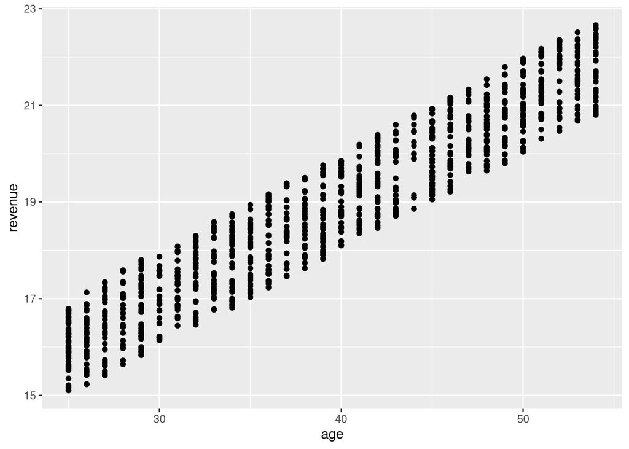

```r
ggplot(merged, aes(age, revenue)) + geom_point()
```

14. Plot a histogram on the set of costs.

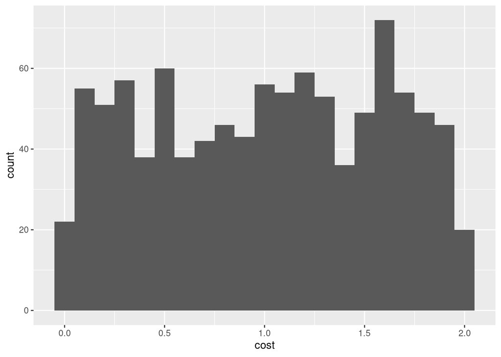

```r
ggplot(merged, aes(cost)) + geom_histogram(binwidth=.1)
```